```python
from IPython.display import HTML

HTML('''<script>
code_show=true;
function code_toggle() {
 if (code_show){
 $('div.input').hide();
 $('div.input_prompt').hide()
 } else {
 $('div.input').show();
 }
 code_show = !code_show
}
$( document ).ready(code_toggle);
</script>
<form action="javascript:code_toggle()"><input type="submit" value="Magic Button."></form>''')
```

# Second Degree Equations Part 2

## Factoring

Remember that we have seen before that we can factor a quadratic expression in a couple of ways

\begin{align} x^2 - 4 &= (x+2)(x-2) & \text{special product} \\ x^2 + 2x - 24 &= (x-4)(x+6) & \text{factor directly} \end{align}

We have also seen that there are some equations that we cannot factor with direct methods, such as

\begin{equation} x^2 - 3x - 7 \end{equation}

But maybe the *quadratic formula* can help factor our expression.

# Some Review

Let's use the *quadratic equation* on $x^2 - x - 6 = 0$. We get

\begin{align} x &= \frac{-b \pm \sqrt{b^2 - 4ac}}{2a} \\ x &= \frac{1 \pm \sqrt{1 - 4(1)(-6)}}{2\cdot 1} \\ x &= \frac{1 \pm\sqrt{1 + 24}}{2} \\ x &= \frac{1 \pm\sqrt{25}}{2} \\ x &= \frac{1 \pm 5}{2} \\ x &= 3, -2 = x_+, x_- \end{align}

## Factoring

Let us try to factor $$x^2 - x - 6$$ using a new method.

Our goal is to find $c_1$ and $c_2$ such that

\begin{equation} x^2 - x - 6 = (x + c_1)(x + c_2) \end{equation}

The *quadratic equation* gives us all $x$ such that $x^2 - x - 6 = 0$. This means that we know an $x$ such that

\begin{equation} x^2 - x - 6 = (x + c_1)(x + c_2) = 0 \end{equation}

In order for $(x + c_1)(x+c_2) = 0$, it *must* be true that eiter $(x + c_1) = 0$ or $(x + c_2) = 0$.

Hmmmmmm.....

## Let's try

\begin{equation} x_+, x_- = 3, -2 \end{equation}

We want to find $c_1$ and $c_2$ so that $(x+c_1)(x+c_2)=0$ only when $x = x_+$ and $x=x_-$

Idea: let $c_1 = -x_+$ and $c_2 = -x_-$!

We get $x^2 - x - 6 = (x - x_+)(x - x_-)$, which is zero *only when* $x=x_+$ or $x=x_-$!

This gives us

\begin{equation} x^2 - x - 6 = \left(x - 3 \right)\left(x + 2 \right) \end{equation}

# Last Comments on Factoring

What happens if $a \neq 1$?

All we have to do is add a factor of $a$ into our factorization!

To factor an expression $ax^2 + bx + c$ for any values of $a, b, c$

Calculate \begin{equation} x_+, x_- = \frac{-b \pm \sqrt{b^2 - 4ac}}{2a} \end{equation}

Factor $$ax^2 + bx + c = a(x - x_+)(x - x_-)$$

## Practice

In *groups of 3*, factor the following expressions with the quadratic formula

\begin{align} x^2 + x - 6 \\ 3x^2 - 9x + 6 \\ 5x^2 + 6x + 1 \end{align}

## Practice Example 1

$$x^2 + x - 6$$\begin{align} x_+, x_- &= \frac{-1 \pm \sqrt{(1)^2 - 4(1)(-6)}}{2(1)} \\ &= \frac{-1 \pm \sqrt{1 + 24}}{2} \\ &= \frac{-1 \pm 5}{2} \\ &= 2, -3 \end{align}\begin{align} x^2 + x - 6 &= (1)(x - x_+)(x - x_-) \\ x^2 + x - 6 &= (x - 2)(x + 3) \end{align}

## Practice Example 2

$$3x^2 - 9x + 6$$\begin{align} x_+, x_- &= \frac{9 \pm \sqrt{(-9)^2 - 4(3)(6)}}{2(3)} \\ &= \frac{9 \pm \sqrt{81 - 72}}{6} \\ &= \frac{9 \pm \sqrt{9}}{6} \\ &= \frac{9 \pm 3}{6} \\ &= 2, 1 \end{align}\begin{align} 3x^2 - 9x + 6 &= (3)(x - x_+)(x - x_-) \\ 3x^2 - 9x + 6 &= 3(x - 2)(x - 1) \end{align}

## Practice Example 3

$$5x^2 + 6x + 1$$\begin{align} x_+, x_- &= \frac{-6 \pm \sqrt{(6)^2 - 4(5)(1)}}{2(5)} \\ &= \frac{-6 \pm \sqrt{36 - 20}}{10} \\ &= \frac{-6 \pm \sqrt{16}}{10} \\ &= \frac{-6 \pm 4}{10} \\ &= \frac{-2}{10}, -1 \end{align}\begin{align} 5x^2 + 6x + 1 &= (5)(x - x_+)(x - x_-) \\ 5x^2 + 6x + 1 &= 5\left(x + \frac{2}{10}\right)(x + 1) = (5x + 1)(x + 1) \end{align}

## Graphing Parabolas

Before we start computing points to graph, let us understand the parts of a second degree equation. Remember we are looking at the graph

\begin{equation} y = ax^2 + bx + c \end{equation}

True or False: If $a$ is positive, the parabola always looks like a $\cup$, and if $a$ is negative, the parabola always looks like a $\cap$.

## Graphing Parabolas

True!

### Positive: 😊, Negative: 😞

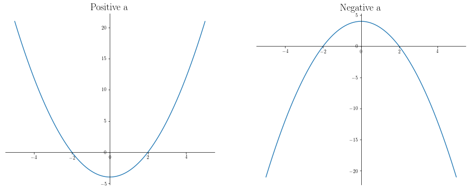

```python
#hideme
x = np.arange(-5, 5, 0.001)
y1 = x**2 - 4
y2 = -1*x**2 + 4

fig = plt.figure(figsize=(17, 6.5))
ax = fig.add_subplot(121)
ax.plot(x, y1)
ax.set_title("Positive a", fontsize=20)
ax.spines['left'].set_position('zero')
ax.spines['right'].set_color('none')
ax.spines['bottom'].set_position('zero')
ax.spines['top'].set_color('none')
ax.xaxis.set_ticks_position('bottom')
ax.yaxis.set_ticks_position('left')


ax = fig.add_subplot(122)
ax.plot(x, y2)
ax.set_title("Negative a", fontsize=20)
ax.spines['left'].set_position('zero')
ax.spines['right'].set_color('none')
ax.spines['bottom'].set_position('zero')
ax.spines['top'].set_color('none')
ax.xaxis.set_ticks_position('bottom')
ax.yaxis.set_ticks_position('left')
```

## Axis of Symmetry

Notice how a parabola is *symmetric* about its minimum/maximum point (called its vertex).

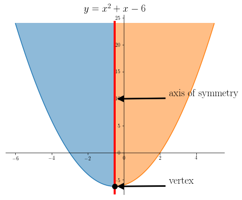

```python
#hideme
xleft = np.arange(-6, -0.5, 0.001)
xright = np.arange(-0.5, 5, 0.001)
yleft = xleft**2 + xleft - 6
yright = xright**2 + xright - 6

fig = plt.figure(figsize=(17, 6.5))
ax = fig.add_subplot(121)
ax.set_title("$y = x^2 + x - 6$", fontsize=20)

ax.plot(xleft, yleft)
ax.fill_between(xleft, yleft, 24.1, alpha=0.5,)

ax.plot(xright, yright)

ax.fill_between(xright, yright, 24.1, alpha=0.5,)


point = np.array([-0.5])
ypoint = point**2 + point - 6



ax.axvline(-0.5, color="red", ymin=-0.9, ymax=0.96, linewidth=4, marker=None, label="Axis")

ax.plot([point], [ypoint], marker='o', markersize=10, color="black")

ax.annotate('vertex', xy=(-0.5, -6.25), xytext=(2.5, -5.8), size=20,
            arrowprops=dict(facecolor='black', shrink=0.05, width=2),
            )

ax.annotate('axis of symmetry', xy=(-0.5, 10), xytext=(2.5, 10.5), size=20,
            arrowprops=dict(facecolor='black', shrink=0.05, width=2),
            )

ax.spines['left'].set_position('zero')
ax.spines['right'].set_color('none')
ax.spines['bottom'].set_position('zero')
ax.spines['top'].set_color('none')
ax.xaxis.set_ticks_position('bottom')
ax.yaxis.set_ticks_position('left')
```

## Axis of Symmetry

For a parabola given as

\begin{equation} y = ax^2 + bx + c \end{equation}

We can calculalte the *$x$ value* for the *axis of symmetry* (the red line from before!) as

\begin{equation} x_{axis} = \frac{-b}{2a} \end{equation}

## Finding the Vertex

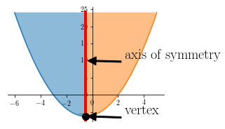

```python
#hideme
xleft = np.arange(-6, -0.5, 0.001)
xright = np.arange(-0.5, 5, 0.001)
yleft = xleft**2 + xleft - 6
yright = xright**2 + xright - 6

fig = plt.figure(figsize=(4, 3))
ax = fig.add_subplot(111)

ax.plot(xleft, yleft)
ax.fill_between(xleft, yleft, 24.1, alpha=0.5,)

ax.plot(xright, yright)

ax.fill_between(xright, yright, 24.1, alpha=0.5,)


point = np.array([-0.5])
ypoint = point**2 + point - 6



ax.axvline(-0.5, color="red", ymin=-0.9, ymax=0.96, linewidth=4, marker=None, label="Axis")

ax.plot([point], [ypoint], marker='o', markersize=10, color="black")

ax.annotate('vertex', xy=(-0.5, -6.25), xytext=(2.5, -5.8), size=20,
            arrowprops=dict(facecolor='black', shrink=0.05, width=2),
            )

ax.annotate('axis of symmetry', xy=(-0.5, 10), xytext=(2.5, 10.5), size=20,
            arrowprops=dict(facecolor='black', shrink=0.05, width=2),
            )

ax.spines['left'].set_position('zero')
ax.spines['right'].set_color('none')
ax.spines['bottom'].set_position('zero')
ax.spines['top'].set_color('none')
ax.xaxis.set_ticks_position('bottom')
ax.yaxis.set_ticks_position('left')
```

If we know the equation of the parabola $y = ax^2 + bx + c$ and we calculated the axis of symmetry

\begin{equation} x_{axis} = \frac{-b}{2a} \end{equation}

then the vertex is located at

\begin{equation} (x_{vertex}, y_{vertex}) = \left(\frac{-b}{2a}, \frac{-\left(b^2 - 4ac\right)}{4a} \right) \end{equation}

## Practice

\begin{equation} (x_{vertex}, y_{vertex}) = \left(\frac{-b}{2a}, \frac{-\left(b^2 - 4ac\right)}{4a} \right) \end{equation}

In *groups of 3*, find the vertex of each of the following parabolas

\begin{align} x^2 + x - 6 \\ 3x^2 - 9x + 6 \\ 5x^2 + 6x + 1 \\ 6x^2 - 24x - 30 \end{align}

## Practice Example 1

**Parabola:** $y = x^2 + x - 6$

\begin{align} x_{vertex} &= \frac{-b}{2a} \\ x_{vertex} &= \frac{-1}{2} = -0.5 \end{align}\begin{align} y_{vertex} &= \frac{-\left(b^2 - 4ac\right)}{4a} \\ y_{vertex} &= \frac{-\left(1^2 - 4(1)(-6)\right)}{4} = \frac{-\left(1 + 24\right)}{4} = \frac{-25}{4} = -6.25 \end{align}\begin{equation} (x_{vertex}, y_{vertex}) = (-0.5, -6.25) \end{equation}

## Practice Example 2

**Parabola:** $y = 3x^2 - 9x + 6$

\begin{align} x_{vertex} &= \frac{-b}{2a} \\ x_{vertex} &= \frac{9}{6} = \frac{3}{2} \end{align}\begin{align} y_{vertex} &= \frac{-\left(b^2 - 4ac\right)}{4a} \\ y_{vertex} &= \frac{-\left((-9)^2 - 4(3)(6)\right)}{4(3)} = \frac{-\left(81 - 72\right)}{12} = \frac{-9}{12} = \frac{-3}{4} \end{align}\begin{equation} (x_{vertex}, y_{vertex}) = (3/2, -3/4) \end{equation}

## Practice Example 3

**Parabola:** $y = 5x^2 + 6x + 1$

\begin{align} x_{vertex} &= \frac{-b}{2a} \\ x_{vertex} &= \frac{-6}{10} = \frac{-3}{5} \end{align}\begin{align} y_{vertex} &= \frac{-\left(b^2 - 4ac\right)}{4a} \\ y_{vertex} &= \frac{-\left(6^2 - 4(5)(1)\right)}{4(5)} = \frac{-\left(36 - 20\right)}{20} = \frac{-16}{20} = \frac{-4}{5} \end{align}\begin{equation} (x_{vertex}, y_{vertex}) = (-3/5, -4/5) \end{equation}

## Practice Example 4

**Parabola:** $y = 6x^2 - 24x - 30$

\begin{align} x_{vertex} &= \frac{-b}{2a} \\ x_{vertex} &= \frac{24}{12} = 2 \end{align}\begin{align} y_{vertex} &= \frac{-\left(b^2 - 4ac\right)}{4a} \\ y_{vertex} &= \frac{-\left(24^2 - 4(6)(-30)\right)}{4(6)} = \frac{-\left(576 + 720\right)}{24} = \frac{-1296}{24} = -54 \end{align}\begin{equation} (x_{vertex}, y_{vertex}) = (2, -54) \end{equation}

We can also use a trick to solve this question. We know that $x_{vertex} = x_{axis}$, so we can just evaluate the parabola at $x_{axis}$ to find $y_{axis}$! This means

\begin{align} y_{vertex} &= 6(x_{vertex})^2 - 24(x_{vertex}) - 30 \\ &= 6(2)^2 - 24(2) - 30 \\ &= 6(4) -48 - 30 \\ &= 24 - 48 - 30 \\ &= -54 \end{align}

## Tomorrow

Tomorrow we will finish learning how to graph parabolas!